# Resolução - Tarefa 3 (Regressão)

Simone Kraievski Nadolny

Última versão em 19/07/22

# Machine Learning em R

## Métodos Supervisionados de Regressão

Nesta terceira tarefa usaremos um dataset relacionado com o serviço de aluguel de bikes em DC, EUA, com registros por hora de aluguel de bikes para o período 2011 a 2012.

#Sobre o aluguel de Bikes em DC, EUA

Os sistemas de compartilhamento de bicicletas são a nova geração de sistemas tradicionais de aluguel de bicicletas onde todo o processo de adesão, aluguel e retorno se tornou automático. Através destes sistemas, o usuário é capaz de alugar facilmente uma bicicleta de uma determinada posição e retornar em outra posição. Atualmente, existem cerca de 500 programas de compartilhamento de bicicletas em todo o mundo, que é composto de mais de 500 mil bicicletas. Hoje, existe um grande interesse nestes sistemas devido ao seu importante papel em questões de tráfego, meio ambiente e saúde.

Além das aplicações interessantes no mundo real dos sistemas de aluguel de bicicletas, as características dos dados gerados por estes sistemas os tornam atraentes para a pesquisa. Ao contrário de outros serviços de transporte, como ônibus ou metrô, a duração da viagem, posição de partida e chegada é explicitamente registrada nestes sistemas. Esta característica transforma o sistema de compartilhamento de bicicletas em uma rede virtual de sensores que pode ser usada para a detecção da mobilidade na cidade. Portanto, espera-se que a maioria dos eventos importantes na cidade possam ser detectados através do monitoramento destes dados.

## Dados

Os dados incluem contagens por hora do aluguel de bicicletas (por membros e usuários casuais) da “Capital Bikeshare” em Washington, DC entre 2011 e 2012, bem como informações meteorológicas sobre esses dias.

Você pode baixar os dados no link abaixo: https://archive.ics.uci.edu/ml/machine-learning-databases/00275/Bike-Sharing-Dataset.zip

As fontes de dados originais se encontram em: - http://capitalbikeshare.com/system-data - http://www.freemeteo.com

O dataset chama-se “hour.csv”. A descrição de cada uma das variáveis pode ser encontrada no arquivo de ajuda do dataset, que pode ser acessado executando “?dcbikeshare” em seu Console.

Para poder trabalhar com os dados, inicialmente sera adicionada as bibliotecas iniciais e lido o arquivo.

# Pergunta 1

Recodificar a variável season para um fator com nomes mais significativos para cada nível: Recodificando a “primavera” (spring) como categoria base. Dados: 1 - winter (inverno) 2 - spring (primavera) 3 - summer (verão) 4 - fall (outono)

## Resposta 1

# Pergunta 2

Recodificar as variáveis binárias holiday e workingday para serem fatores Níveis: 0 - no (não) 1 - yes (sim)

Considere no como categoria base.

## Resposta 2

# Pergunta 3

Recodificar a variável yr para ser um fator com níveis Níveis: 0 - 2011 1 - 2012,

Considere 2011 como categoria base.

## Resposta 3

# Pergunta 4

Recodifique a variável weathersit para factor Níveis: 1 - claro 2 - névoa 3 - precip leve 4 - precip pesada

Considerando claro como categoria base.

## Resposta 4

# Pergunta 5

Crie novas variáveis para as variáveis temperatura (temp), sensação térmica (atemp), umidade (hum) e velocidade do vendo (windspeed) calculando os valores brutos. As colunas temperatura (temp), sensação térmica (atemp), umidade (hum) e velocidade do vento (windspeed) estão normalizadas (0-1). - temp: para converter a graus Celsius multiplique por 41 (valor máximo) - atemp: idem anterior, multiplique por 50 (valor máximo) - hum: multiplique por 100 (valor máximo) - windspeed: multiplique por 67 (valor máximo)

## Resposta 5

# Pergunta 6

Recodifique a variavel weekday para factor Níveis: 1: 2a-f 2: 3a-f 3: 4a-f 4: 5a-f 5: 6a-f 6: sábado 0: domingo (na tarefa estava dizendo que domingo era o 7, porém não existia 7 nos dados e existia 0, então foi usado 0 como domingo)

Considerando 2a-f como categoria base.

## Resposta 6

# Pergunta 7

Recodifique as variáveis hr para factor e mnth para factor. hr factor com 24 níveis (de 0 a 23) e mnth para factor com 12 níveis (janeiro a dezembro).

## Resposta 7

# Pergunta 8

Recrie visualização a seguir, e interprete-a no contexto dos dados. Dica: Você precisará usar uma das variáveis que você criou acima. A temperatura plotada é a sensação térmica. Antes de realizar o gráfico verifique que o tipo da variável dteday deve ser Date e não chr.

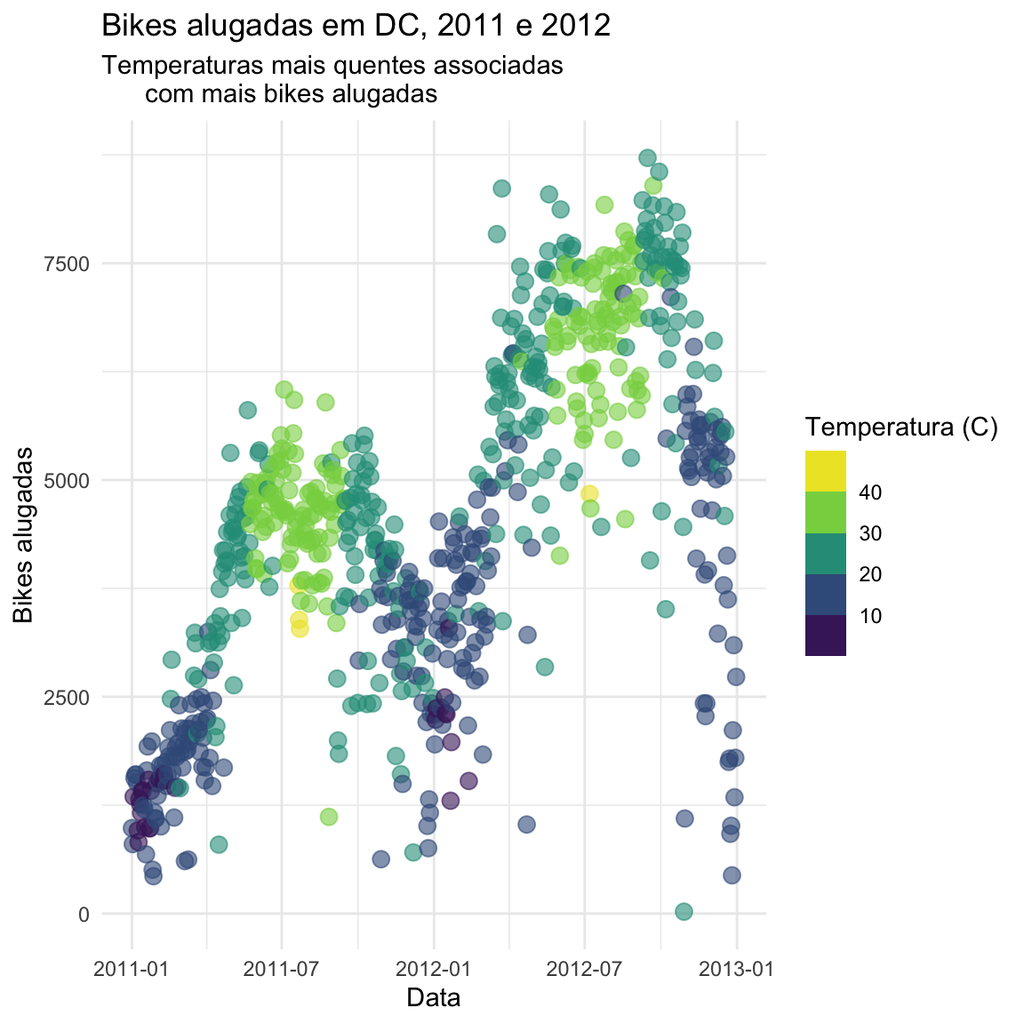

Imagem base

## Resposta 8

Verificando se a variavel dteday está em formato de data:

```
## [1] "Date"
```

Como ela está em formato de “Date” já pode-se começar a plotar o gráfico solicitado

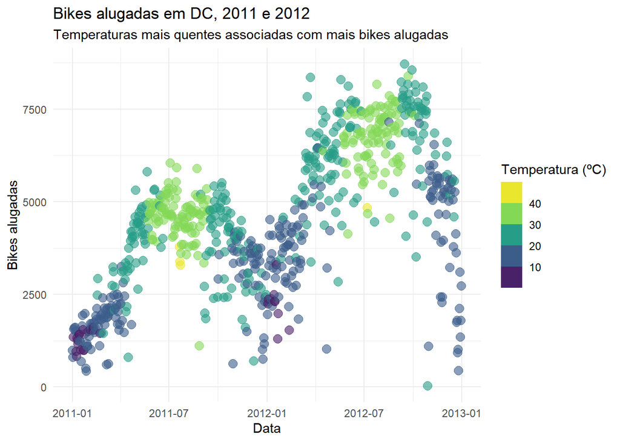

# Pergunta 9

Recrie a visualização abaixo, mostrando a relação entre o aluguel de bicicletas e a estação do ano (season). Interprete-a no contexto dos dados.

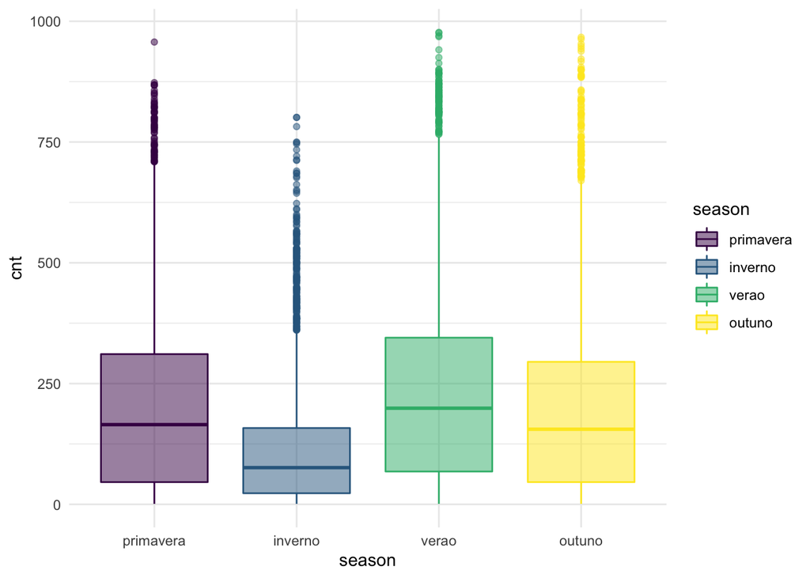

## Resposta 9

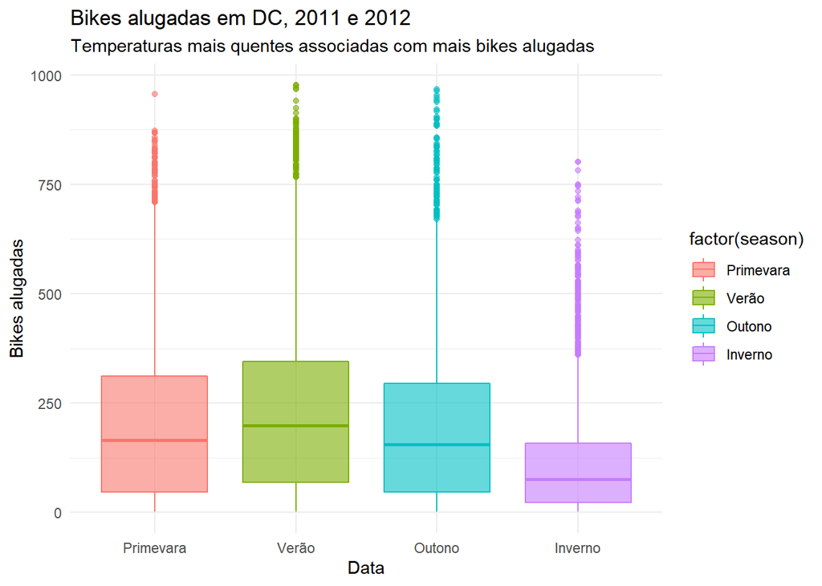

# Pergunta 10

Separe o dataset em dois grupos, treinamento e teste, sendo a proporção 75 e 25 respectivamente, use obrigatoriamente o tidymodels (escoha quais atributos irá usar e quais não e justifique suas escolhas).

## Resposta 10

Inicialmente é necessário fazer um filtro no data frame e adicionar as bibliotecas necessárias, logo será retiradas algumas colunas que não serão necessárias. A tabela inicial consta com os seguintes dados:

Data summary

| Name | bike_shared |
| --- | --- |
| Number of rows | 17379 |
| Number of columns | 17 |
| _______________________ |  |
| Column type frequency: |  |
| Date | 1 |
| factor | 8 |
| numeric | 8 |
| ________________________ |  |
| Group variables | None |

**Variable type: Date**

| skim_variable | n_missing | complete_rate | min | max | median | n_unique |
| --- | --- | --- | --- | --- | --- | --- |
| dteday | 0 | 1 | 2011-01-01 | 2012-12-31 | 2012-01-02 | 731 |

**Variable type: factor**

| skim_variable | n_missing | complete_rate | ordered | n_unique | top_counts |
| --- | --- | --- | --- | --- | --- |
| season | 0 | 1 | FALSE | 4 | Ver: 4496, Pri: 4409, Inv: 4242, Out: 4232 |
| yr | 0 | 1 | FALSE | 2 | 202: 8734, 201: 8645 |
| mnth | 0 | 1 | FALSE | 12 | Mai: 1488, Jul: 1488, Dez: 1483, Ago: 1475 |
| hr | 0 | 1 | FALSE | 24 | 16: 730, 17: 730, 13: 729, 14: 729 |
| holiday | 0 | 1 | FALSE | 2 | Não: 16879, Sim: 500 |
| weekday | 0 | 1 | FALSE | 7 | Sáb: 2512, Dom: 2502, 6a-: 2487, 2a-: 2479 |
| workingday | 0 | 1 | FALSE | 2 | Sim: 11865, Não: 5514 |
| weathersit | 0 | 1 | FALSE | 4 | Cla: 11413, Név: 4544, Pre: 1419, Pre: 3 |

**Variable type: numeric**

| skim_variable | n_missing | complete_rate | mean | sd | p0 | p25 | p50 | p75 | p100 | hist |
| --- | --- | --- | --- | --- | --- | --- | --- | --- | --- | --- |
| instant | 0 | 1 | 8690.00 | 5017.03 | 1.00 | 4345.50 | 8690.00 | 13034.50 | 17379 | ▇▇▇▇▇ |
| temp | 0 | 1 | 20.38 | 7.89 | 0.82 | 13.94 | 20.50 | 27.06 | 41 | ▂▇▇▇▁ |
| atemp | 0 | 1 | 23.79 | 8.59 | 0.00 | 16.66 | 24.24 | 31.06 | 50 | ▁▆▇▆▁ |
| hum | 0 | 1 | 62.72 | 19.29 | 0.00 | 48.00 | 63.00 | 78.00 | 100 | ▁▃▇▇▆ |
| windspeed | 0 | 1 | 12.74 | 8.20 | 0.00 | 7.00 | 13.00 | 17.00 | 57 | ▇▆▂▁▁ |
| casual | 0 | 1 | 35.68 | 49.31 | 0.00 | 4.00 | 17.00 | 48.00 | 367 | ▇▁▁▁▁ |
| registered | 0 | 1 | 153.79 | 151.36 | 0.00 | 34.00 | 115.00 | 220.00 | 886 | ▇▃▁▁▁ |
| cnt | 0 | 1 | 189.46 | 181.39 | 1.00 | 40.00 | 142.00 | 281.00 | 977 | ▇▃▁▁▁ |

Após a análise dos tipos de dados pode ser interessante também uma análise dos valores encontrados, que serão apresentados a seguir:

```
##     instant          dteday                 season        yr
##  Min.   :    1   Min.   :2011-01-01   Primevara:4409   2011:8645
##  1st Qu.: 4346   1st Qu.:2011-07-04   Verão    :4496   2021:8734
##  Median : 8690   Median :2012-01-02   Outono   :4232
##  Mean   : 8690   Mean   :2012-01-02   Inverno  :4242
##  3rd Qu.:13034   3rd Qu.:2012-07-02
##  Max.   :17379   Max.   :2012-12-31
##
##        mnth            hr        holiday        weekday     workingday
##  Maio    :1488   16     :  730   Não:16879   2a-f   :2479   Não: 5514
##  Julho   :1488   17     :  730   Sim:  500   3a-fa  :2453   Sim:11865
##  Dezembro:1483   13     :  729               4a-f   :2475
##  Agosto  :1475   14     :  729               5a-f   :2471
##  Março   :1473   15     :  729               6a-f   :2487
##  Outubro :1451   12     :  728               Sábado :2512
##  (Other) :8521   (Other):13004               Domingo:2502
##           weathersit         temp           atemp            hum
##  Claro         :11413   Min.   : 0.82   Min.   : 0.00   Min.   :  0.00
##  Névoa         : 4544   1st Qu.:13.94   1st Qu.:16.66   1st Qu.: 48.00
##  Precip. leve  : 1419   Median :20.50   Median :24.24   Median : 63.00
##  Precip. pesada:    3   Mean   :20.38   Mean   :23.79   Mean   : 62.72
##                         3rd Qu.:27.06   3rd Qu.:31.06   3rd Qu.: 78.00
##                         Max.   :41.00   Max.   :50.00   Max.   :100.00
##
##    windspeed          casual         registered         cnt
##  Min.   : 0.000   Min.   :  0.00   Min.   :  0.0   Min.   :  1.0
##  1st Qu.: 7.002   1st Qu.:  4.00   1st Qu.: 34.0   1st Qu.: 40.0
##  Median :12.998   Median : 17.00   Median :115.0   Median :142.0
##  Mean   :12.737   Mean   : 35.68   Mean   :153.8   Mean   :189.5
##  3rd Qu.:16.998   3rd Qu.: 48.00   3rd Qu.:220.0   3rd Qu.:281.0
##  Max.   :56.997   Max.   :367.00   Max.   :886.0   Max.   :977.0
##
```

```
##
## Call:
## lm(formula = cnt ~ ., data = bike_shared)
##
## Residuals:
##        Min         1Q     Median         3Q        Max
## -6.298e-11 -9.000e-14  1.000e-14  1.000e-13  3.843e-10
##
## Coefficients: (1 not defined because of singularities)
##                            Estimate Std. Error    t value Pr(>|t|)
## (Intercept)               5.368e-09  7.558e-10  7.103e+00 1.27e-12 ***
## instant                   1.492e-14  2.114e-15  7.060e+00 1.73e-12 ***
## dteday                   -3.582e-13  5.046e-14 -7.098e+00 1.31e-12 ***
## seasonVerão              -9.103e-14  1.517e-13 -6.000e-01 0.548546
## seasonOutono             -5.718e-13  1.752e-13 -3.263e+00 0.001106 **
## seasonInverno            -6.246e-13  1.483e-13 -4.212e+00 2.55e-05 ***
## yr2021                    1.278e-12  9.851e-13  1.297e+00 0.194612
## mnthFevereiro            -3.986e-13  1.485e-13 -2.684e+00 0.007284 **
## mnthMarço                -2.104e-13  2.130e-13 -9.880e-01 0.323309
## mnthAbril                -2.669e-14  3.128e-13 -8.500e-02 0.932013
## mnthMaio                 -4.267e-13  3.832e-13 -1.114e+00 0.265476
## mnthJunho                -7.452e-14  4.550e-13 -1.640e-01 0.869909
## mnthJulho                -1.281e-13  5.393e-13 -2.380e-01 0.812203
## mnthAgosto               -5.844e-14  6.116e-13 -9.600e-02 0.923878
## mnthSetembro              8.427e-14  6.819e-13  1.240e-01 0.901652
## mnthOutubro               1.187e-12  7.609e-13  1.560e+00 0.118802
## mnthNovembro              1.121e-12  8.416e-13  1.332e+00 0.182852
## mnthDezembro              1.289e-12  9.129e-13  1.412e+00 0.158004
## hr1                      -9.661e-13  1.628e-13 -5.933e+00 3.04e-09 ***
## hr2                       5.539e-13  1.635e-13  3.388e+00 0.000707 ***
## hr3                      -1.395e-12  1.649e-13 -8.461e+00  < 2e-16 ***
## hr4                       1.535e-12  1.652e-13  9.291e+00  < 2e-16 ***
## hr5                      -1.084e-12  1.640e-13 -6.609e+00 3.97e-11 ***
## hr6                      -1.911e-12  1.640e-13 -1.165e+01  < 2e-16 ***
## hr7                      -4.350e-13  1.703e-13 -2.555e+00 0.010626 *
## hr8                       2.712e-13  1.841e-13  1.473e+00 0.140717
## hr9                      -9.122e-13  1.684e-13 -5.417e+00 6.15e-08 ***
## hr10                     -9.060e-13  1.668e-13 -5.431e+00 5.69e-08 ***
## hr11                     -9.371e-13  1.695e-13 -5.529e+00 3.27e-08 ***
## hr12                     -9.537e-13  1.728e-13 -5.518e+00 3.48e-08 ***
```

[output cut: 19 more lines]

```
## weathersitNévoa          -1.123e-13  5.855e-14 -1.918e+00 0.055159 .
## weathersitPrecip. leve   -5.083e-13  9.973e-14 -5.097e+00 3.49e-07 ***
## weathersitPrecip. pesada -9.288e-13  1.794e-12 -5.180e-01 0.604583
## temp                      4.422e-14  2.200e-14  2.010e+00 0.044399 *
## atemp                    -1.470e-14  1.868e-14 -7.870e-01 0.431157
## hum                       4.593e-15  1.711e-15  2.684e+00 0.007277 **
## windspeed                -4.411e-15  3.211e-15 -1.374e+00 0.169518
## casual                    1.000e+00  8.052e-16  1.242e+15  < 2e-16 ***
## registered                1.000e+00  2.979e-16  3.356e+15  < 2e-16 ***
## ---
## Signif. codes:  0 '***' 0.001 '**' 0.01 '*' 0.05 '.' 0.1 ' ' 1
##
## Residual standard error: 3.098e-12 on 17322 degrees of freedom
## Multiple R-squared:      1,  Adjusted R-squared:      1
## F-statistic: 1.064e+30 on 56 and 17322 DF,  p-value: < 2.2e-16
```

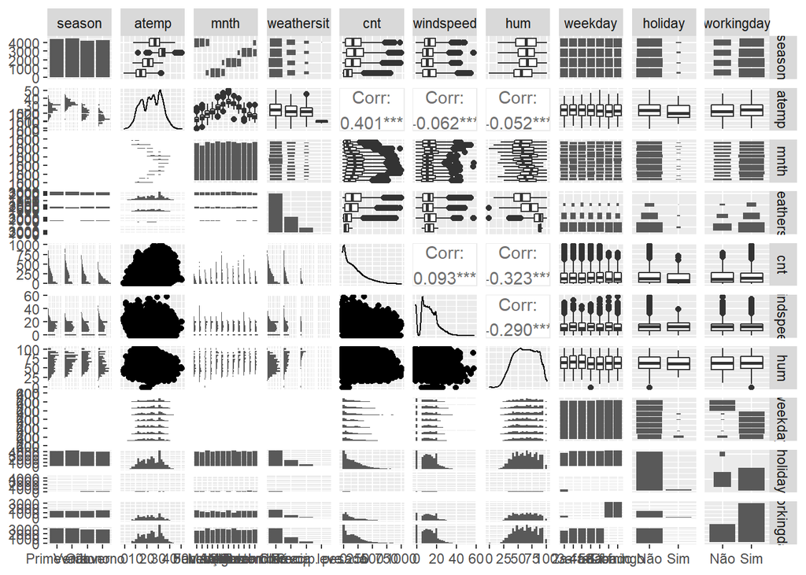

Das 17 colunas apresentadas, podemos desconsiderar para as análises a “instant”, “yr” visto que só existem dois factores e existe a variável “dteday”, mês e hora serão mantidas para facilitar análises mais sazonais, também não será inclusa nas análises o “temp” visto que o atemp já irá substituir essa variável que oferece informações semelhantes, “hum” e “windspeed” não entraram nas análises, também não entrará o “casual” ou o “registered” visto que esses dois dados já estão inclusos na sua soma em cnt.

# Pergunta 11

Crie um objeto de validação cruzada, com k=10 usando tidymodels, mostre o código. Use este objeto para todas as questões a seguir.

## Resposta 11

# Pergunta 12

Ajuste um modelo linear prevendo o total de aluguéis de bicicletas a partir dos atributos presentes no dataset. Calcule o R2, o RMSE e o MAE.

## Resposta 12

```
## # A tibble: 3 × 6
##   .metric .estimator    mean     n std_err .config
##   <chr>   <chr>        <dbl> <int>   <dbl> <chr>
## 1 mae     standard    75.3      10 0.435   Preprocessor1_Model1
## 2 rmse    standard   102.       10 0.722   Preprocessor1_Model1
## 3 rsq     standard     0.683    10 0.00290 Preprocessor1_Model1
```

# Pergunta 13

Ajuste um modelo de árvore de decisão prevendo o total de aluguéis de bicicletas a partir dos atributos presentes no dataset. Calcule o R2, o RMSE e o MAE.

## Resposta 13

```
## # A tibble: 3 × 6
##   .metric .estimator    mean     n std_err .config
##   <chr>   <chr>        <dbl> <int>   <dbl> <chr>
## 1 mae     standard    95.3      10 1.08    Preprocessor1_Model1
## 2 rmse    standard   127.       10 1.17    Preprocessor1_Model1
## 3 rsq     standard     0.507    10 0.00930 Preprocessor1_Model1
```

# Pergunta 14

Utilize o algoritmo Random Forests para prever o total de aluguéis de bicicletas a partir dos atributos presentes no dataset. Calcule o R2, o RMSE e o MAE.

## Resposta 14

```
## # A tibble: 3 × 6
##   .metric .estimator   mean     n std_err .config
##   <chr>   <chr>       <dbl> <int>   <dbl> <chr>
## 1 mae     standard   41.9      10 0.240   Preprocessor1_Model1
## 2 rmse    standard   62.1      10 0.438   Preprocessor1_Model1
## 3 rsq     standard    0.895    10 0.00219 Preprocessor1_Model1
```

# Pergunta 15

Qual dos três modelos foi melhor? Dica: compare os R2, os RMSE e os MAE usando uma tabela.

## Resposta 15

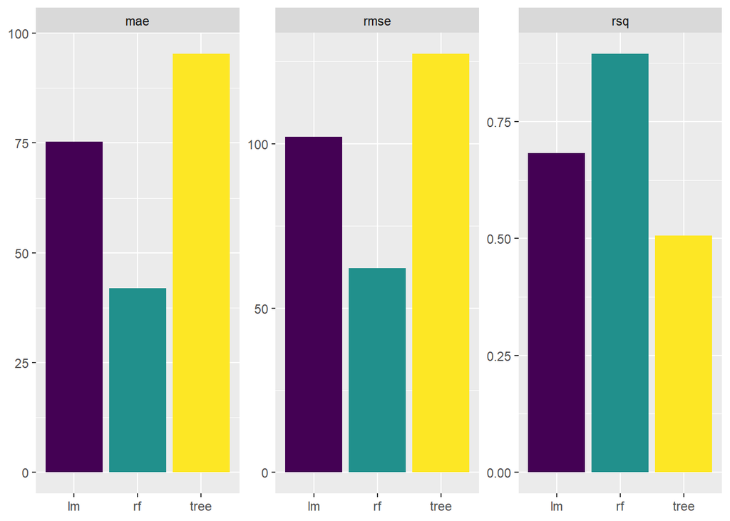

Assim, o melhor modelo é o do Random Forests

[output not shown]

# Pergunta 16

Use o melhor modelo para calcular o R2, o RMSE e o MAE no dataset de teste. Grafique o total de aluguéis (cnt) no eixo x e o valor estimado no eixo y

## Resposta 16

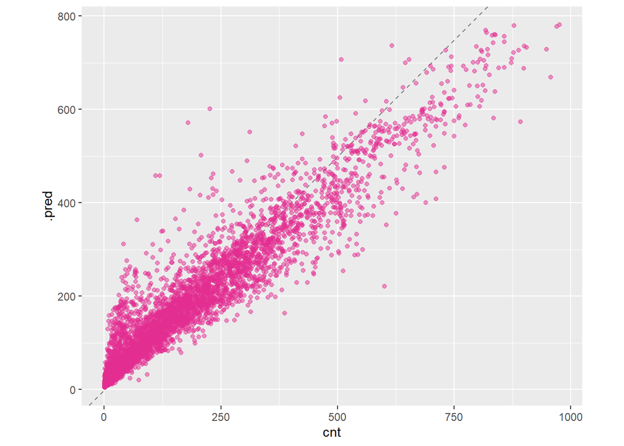

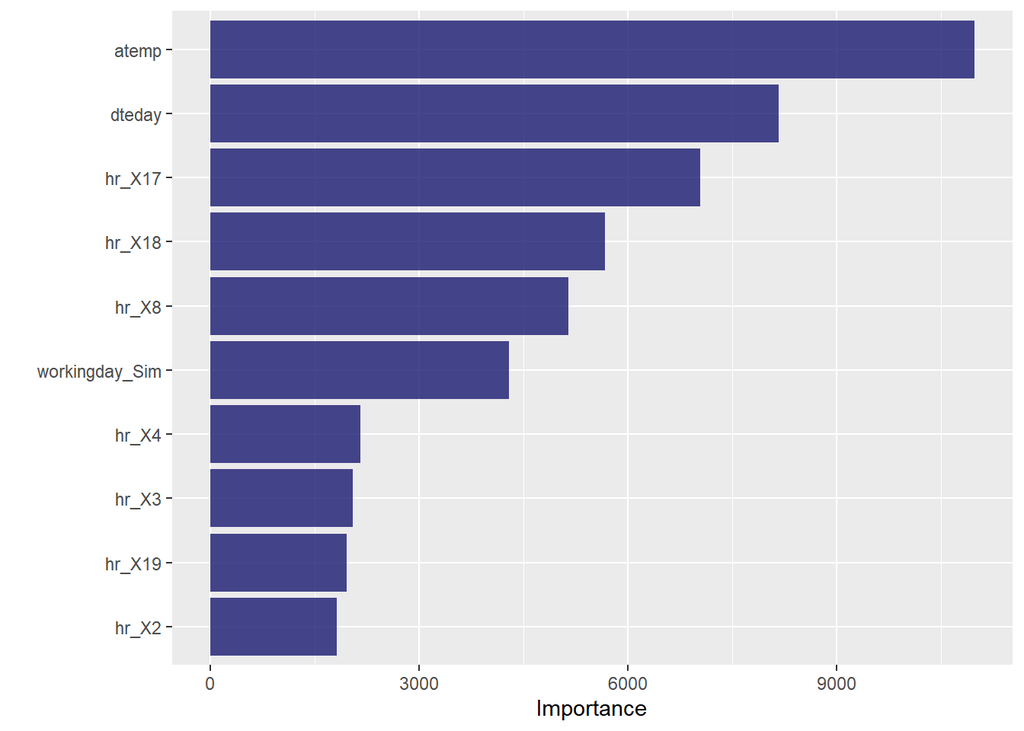